# Deseq comparisons

George Savva

June 2025

Code to generate figure 4 and associated senstivity analyses, tables etc. This is an R source file that can be run with ‘source’ or spun into a report with rmarkdown::render Don’t output messages or warnings in the report (comment this out if you want the warnings and messages)

```r
knitr::opts_chunk$set(message = FALSE, warning = FALSE)
```

Load packages

```r
library(data.table) # Data wrangling
library(here)       # Locating files
library(DESeq2)     # Differential abundance
library(ggplot2)    # Plotting
library(GGally)     # Pairs plot
library(patchwork)  # Multi-panel plots
```

I ran the analyses with and without pairing, and with and without the excluded replicate pair.

This iterates over all of the combinations of these options so generates the graphs and tables for different values of DROPONE and PAIRED.

You can’t split a for loop across RMD chunks, so for this file I’ve hard-coded the primary analysis parameters.

```r
PAIRED=TRUE
DROPONE=TRUE
# for(PAIRED in c(FALSE,TRUE)){
#   for(DROPONE in c(FALSE,TRUE)){
```

Read and encode the data, create the master DDS object

```r
  Plant_data_3_reps <- read.csv(here("RNA_seq data","Plants","3_rep_analysis","Annotated_counts_in_plants_2.csv"), row.names = 1)
  # Extract gene IDs and names.
  plantGeneNames <- Plant_data_3_reps |> as.data.table(keep.rownames = "Gene") |> _[, .(Gene,NamePlant=Name,locus_tagPlant=locus_tag)]
  gene_ids <- rownames(Plant_data_3_reps)
  counts <- as.matrix(Plant_data_3_reps[, c("PK1", "PK2", "PK3", "VS1", "VS2", "VS3")])
  # Replace NA values with 0
  counts[is.na(counts)] <- 0
  # Remove genes with all zero counts from the plant dataset
  plant_counts <- counts[rowSums(counts) > 0, ]
  # Create metadata
  plant_metadata <- data.frame(
    row.names = colnames(counts),
    condition = factor(c("Control", "Control", "Control", "Treatment", "Treatment", "Treatment")),
    pair = factor(c(1, 2, 3, 1, 2, 3))
  )

  # Load the in vitro data
  invitrocounts =fread("RNA_seq data/In Vitro/Annotated_counts_in_vitro2.csv")
  IVGeneNames <- invitrocounts[, .(Gene=Geneid,NameIV=Name,locus_tagIV=Genomeid)]
  # Extract gene IDs and names
  counts <- as.matrix(invitrocounts[, c("PK1", "PK2", "PK3","VS1", "VS2", "VS3")])
  colnames(counts) <- paste0("IV_",colnames(counts))
  rownames(counts) <- invitrocounts$Geneid
  # Replace NA values with 0
  counts[is.na(counts)] <- 0
  # Remove genes with all zero counts
  iv_counts <- counts[rowSums(counts) > 0, ]
  # Create metadata
  iv_metadata <- data.frame(
    row.names = colnames(counts),
    condition = factor(c("Control", "Control","Control", "Treatment","Treatment", "Treatment")),
    pair = factor(c(4,5,6,4,5,6))
  )

  ##### CONCATENATE INTO A MASTER ANALYSIS DATASET
  metadata <- rbind(plant_metadata,iv_metadata)[, c("condition","pair")]
  metadata$environment = rep(c("Plant","IV"),each=6) |> factor()
  metadata$pairwithingroup = factor(rep(rep(1:3,2),2))

  #### THERE IS ONE MORE ROW IN THE IV DATA?  "nbis-gene-1746"  GETS DROPPED FROM THE PLANT DATASET
  counts <- merge.data.frame(plant_counts,iv_counts,by=0)
  rownames(counts) <- counts$Row.names
  counts$Row.names <- NULL

  # Create DESeq dataset object with a simple design which gets overwritten later
  dds3 <- DESeqDataSetFromMatrix(countData = counts,
                                 colData   = metadata,
                                 design    = ~ condition + environment)
```

Check that the counts of genes are similar magnitude across all reps and conditions.  
This gives us some reassurance that the genes are lined up correctly and are measuring roughly the same thing!

This does not depend on the analysis options, its just descriptive.

```r
allCounts <- ggpairs(counts[1:1000,],upper = list(continuous = wrap(ggally_cor, method = "spearman"))) +
  scale_x_log10() +
  scale_y_log10()
```

We only need the pairwise counts file once as it’s descriptive.

```r
ggsave(plot=allCounts, filename = "pairwiseCounts.png",width=10,height=10)
```

Now we set up the design that we actually want. Following the guidance from the DESeq vignette on pairing and nesting

```r
  if(PAIRED) {
    formula_main <- ~ environment + environment:condition + environment:pairwithingroup
    formula_short <- ~ condition + pairwithingroup # can't use 'pair' here because it will complain about missing levels.
  }
  if(PAIRED==FALSE){
    formula_main <- ~ environment + environment:condition
    formula_short <- ~ condition
  }

  design(dds3) <- formula_main

  if(DROPONE){
    dds3 <- dds3[,dds3$pair!=1]
    colData(dds3)$pairwithingroup <- droplevels(colData(dds3)$pairwithingroup)
    colData(dds3)$pairwithingroup <- factor(c(1,2,1,2,1,2,3,1,2,3))
  }
```

These DDS objects are for running the DESeq in the plant or IV environments independently  
Checking that the fact we’re running all the samples in the same model doesn’t cause any weirdness, given the differences in variance between the pairs.

```r
  dds3_plantonly <- dds3[, dds3$environment=="Plant"]
  dds3_invitroonly <- dds3[, dds3$environment=="IV"]

  design(dds3_plantonly) <- formula_short
  design(dds3_invitroonly) <- formula_short
```

Need to make sure there aren’t any empty levels

```r
  colData(dds3_plantonly)$pairwithingroup <- droplevels(colData(dds3_plantonly)$pairwithingroup)
  colData(dds3_invitroonly)$pairwithingroup <- droplevels(colData(dds3_invitroonly)$pairwithingroup)
```

Now we can get generate the deseq and get the results

```r
## Generate the deseq results
  if(DROPONE==TRUE & PAIRED==TRUE){
    # Comes from the deseq vignette on paired tests in unbalanced groups
    # If we don't do this we have unidentifiable matrix
    m1 <- model.matrix( formula_main, colData(dds3))
    m1 |> unname()
    all.zero <- apply(m1, 2, function(x) all(x==0))
    all.zero
    idx <- which(all.zero)
    m1 <- m1[,-idx]
    dds3 <- dds3 |> DESeq(full = m1)
  } else { dds3 <- dds3 |> DESeq() }

  dds3_plantonly <- dds3_plantonly |> DESeq()
  dds3_invitroonly <- dds3_invitroonly |> DESeq()
```

Now Extract the interaction effects and main effects (along with shrunk estimators, p-values etc)

```r
  interactionEffects <- results(dds3, contrast=list("environmentIV.conditionTreatment","environmentPlant.conditionTreatment")) |> as.data.table(keep.rownames="Gene")
  plantEffects <- results(dds3, name = "environmentPlant.conditionTreatment") |> as.data.table(keep.rownames="Gene")
  invitroEffects <- results(dds3, name = "environmentIV.conditionTreatment") |> as.data.table(keep.rownames="Gene")

  dds3.results.plant.shrunk <- lfcShrink(dds3, coef="environmentPlant.conditionTreatment") |> as.data.table(keep.rownames="Gene")
  dds3.results.invitro.shrunk <- lfcShrink(dds3, coef="environmentIV.conditionTreatment")  |> as.data.table(keep.rownames="Gene")

  plantOnlyEffects <- results(dds3_plantonly,contrast = c("condition", "Treatment", "Control")) |> as.data.table(keep.rownames="Gene")
  invitroOnlyEffects <- results(dds3_invitroonly,contrast = c("condition", "Treatment", "Control")) |> as.data.table(keep.rownames="Gene")
```

Combine the different effects into one table

```r
  interactionEffects=interactionEffects[, .(Gene,INT_L2FC=log2FoldChange, INT_pvalue=pvalue, INT_padj=padj )]
  plantEffects=plantEffects[, .(Gene,Plant_L2FC=log2FoldChange, Plant_pvalue=pvalue, Plant_padj=padj )]
  invitroEffects=invitroEffects[, .(Gene,IV_L2FC=log2FoldChange, IV_pvalue=pvalue, IV_padj=padj )]

  invitroEffectsShrunk = dds3.results.invitro.shrunk[ , .(Gene,IVShrunk_L2FC=log2FoldChange, IVShrunk_pvalue=pvalue, IVShrunk_padj=padj ,IVShrunk_baseMean=baseMean)]
  plantEffectsShrunk = dds3.results.plant.shrunk[ , .(Gene,PlantShrunk_L2FC=log2FoldChange, PlantShrunk_pvalue=pvalue, PlantShrunk_padj=padj,PlantShrunk_baseMean=baseMean )]

  plantOnlyEffects=plantOnlyEffects[, .(Gene,PlantOnly_baseMean=baseMean,PlantOnly_L2FC=log2FoldChange, PlantOnly_pvalue=pvalue, PlantOnly_padj=padj )]
  invitroOnlyEffects=invitroOnlyEffects[, .(Gene,InvitroOnly_baseMean=baseMean,InvitroOnly_L2FC=log2FoldChange, InvitroOnly_pvalue=pvalue, InvitroOnly_padj=padj )]

  combinedEffects <- interactionEffects[plantEffects,on="Gene"][invitroEffects,on="Gene"][plantGeneNames,on="Gene"] |>
    _[IVGeneNames,on="Gene"][invitroOnlyEffects,on="Gene"][plantOnlyEffects,on="Gene"] |>
    _[invitroEffectsShrunk,on="Gene"][plantEffectsShrunk,on="Gene"]


## Just checking that all of the names and tags still line up across groups
  combinedEffects[,all.equal(NamePlant,NameIV)]
```

```
## [1] TRUE
```

```r
  combinedEffects[,all.equal(locus_tagIV,locus_tagPlant)]
```

```
## [1] TRUE
```

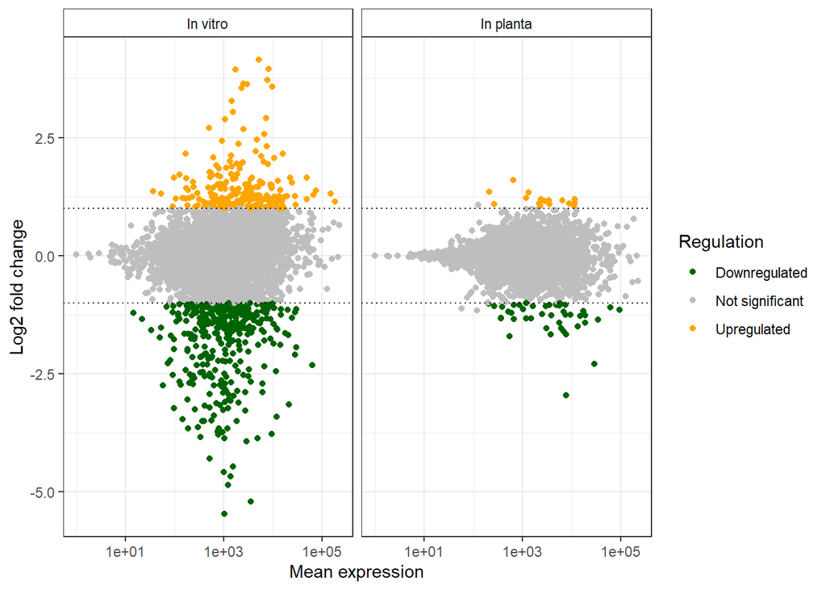

```r
## All good!

## Get the numbers of genes that are considered up- or down- regulated by each method:

combinedEffectsLong <- combinedEffects |> melt(id.vars = c("Gene","NamePlant","locus_tagPlant","NameIV","locus_tagIV")) |> _[, c("Environment","score") := tstrsplit(variable,"_",fixed=TRUE)] |>
  dcast(Gene + Environment ~ score, value.var="value") |>
  _[ , regulated:="Neither"] |>
  _[ L2FC>=1 & padj<=0.05 , regulated:="Up"] |>
  _[ L2FC<= -1 & padj<=0.05 , regulated:="Down"]

fwrite(file = sprintf("numbersOfDAGenes_DROPONE_%s_PAIRED_%s.csv",DROPONE,PAIRED), x=combinedEffectsLong[, table(regulated,Environment)])


fig4c <- ggplot(combinedEffects) + aes(x=IV_L2FC, y=Plant_L2FC,col=INT_padj<0.05)+ geom_point(size=1) +
  scale_color_manual(values=c("black","red"),na.value = NA,name="Interaction effect",
                     labels=c("FALSE"="Not significant (adj.p > 0.05)",
                              "TRUE"="Significant (adj.p < 0.05)")) + coord_fixed() +
  geom_hline(yintercept=c(-1,1),lty="dotted") +
  geom_vline(xintercept=c(-1,1),lty="dotted") + theme_bw() +
  geom_abline(lty="dashed") + stat_smooth(method="lm",col="black")+
  labs(x="Log 2 fold change (in vitro)", y="Log 2 fold change (in planta)")

fig4cShrunk <- ggplot(combinedEffects) + aes(x=IVShrunk_L2FC, y=PlantShrunk_L2FC,col=INT_padj<0.05)+ geom_point(size=1) +
  scale_color_manual(values=c("black","red"),na.value = NA) + coord_fixed() +
  geom_hline(yintercept=c(-1,1),lty="dotted") +
  geom_vline(xintercept=c(-1,1),lty="dotted") + theme_bw() +
  geom_abline() + theme(legend.position="none") +
  labs(x="Shrunk Log 2 fold change (in vitro)", y="Shrunk Log 2 fold change (in planta)")


(fig4a <- ggplot(combinedEffectsLong[Environment%in%c("IVShrunk","PlantShrunk")]) +
  aes(x=baseMean,y=L2FC,col=regulated) +
  geom_point() +
  facet_wrap(~Environment,labeller=labeller(.cols=c("IVShrunk"="In vitro","PlantShrunk"="In planta")))+
  scale_x_log10() +
  geom_hline(yintercept=c(-1,1),lty="dotted") +
  theme_bw() + theme(strip.background = element_rect(fill = NA))+
  scale_color_manual(values=c("Down"="darkgreen","Neither"="grey",Up="orange"),name="Regulation",labels=c("Down"="Downregulated","Neither"="Not significant","Up"="Upregulated")) +
  labs(x="Mean expression", y ="Log2 fold change"))
```

Make figure 4

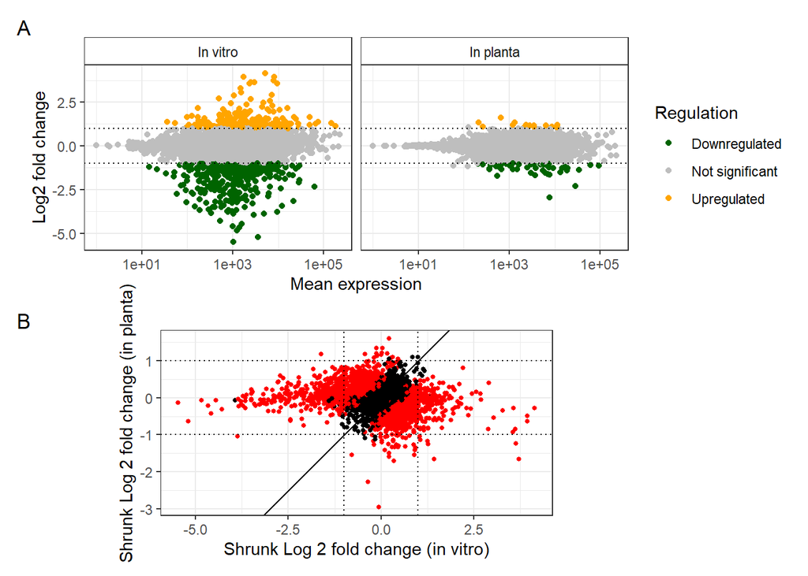

```r
fig4a / fig4cShrunk + plot_layout(heights=c(1,1)) + plot_annotation(tag_levels = "A")
```

```r
ggsave(sprintf("Figure4.png_DROPONE_%s_PAIRED_%s.png",DROPONE,PAIRED),width=8,height=8)
```

Spearman correlation between L2FC in the different environments

```r
combinedEffects[, cor.test(IV_L2FC,Plant_L2FC,use = "complete.obs",method="spearman")]
```

```
##
##  Spearman's rank correlation rho
##
## data:  IV_L2FC and Plant_L2FC
## S = 3.7568e+10, p-value < 2.2e-16
## alternative hypothesis: true rho is not equal to 0
## sample estimates:
##        rho
## -0.1931275
```

```r
dds3.results.plant.shrunk <- lfcShrink(dds3, coef="environmentPlant.conditionTreatment")
dds3.results.invitro.shrunk <- lfcShrink(dds3, coef="environmentIV.conditionTreatment")
```

Generate the estimate of LFC within each pair by extracting the normalised counts from the deseq model

```r
normalisedCounts_all <- counts(dds3, normalized=TRUE) |> as.data.frame() |>
  as.data.table(keep.rownames = "Gene") |> setNames(c("Gene",paste(sep = "_",colData(dds3)$environment,colData(dds3)$pair,colData(dds3)$condition))) |>
  melt(id.vars="Gene") |> _[, c("Env","Rep","Cond") := tstrsplit(variable,"_",fixed=TRUE)] |>
  dcast(Env+Rep+Gene ~ Cond, value.var="value") |> _[, LFC:=log2(Treatment/Control)] |> _[ , Pair:=paste0(Env,Rep)] |>
  _[ !is.finite(LFC) , LFC := NA] |>
  dcast(Gene ~ Pair , value.var="LFC")
```

Make the comparison of the LFCs across pairs.

```r
lfccomp <- GGally::ggpairs(normalisedCounts_all[,-1]) + ggtitle("Pairwise correlation between estimated log2-fold change arising within each pair of samples") + theme_bw()

ggsave(plot = lfccomp,sprintf("LFCcomparison_DROPONE_%s_PAIRED_%s.png",DROPONE,PAIRED),width=8,height=8)
fwrite(file = sprintf("allDeseqOutput_DROPONE_%s_PAIRED_%s.csv",DROPONE,PAIRED),x = combinedEffects)

#   }
# }     # THESE ARE THE CLOSE BRACES FOR THE FOR LOOP I
```

Do some model diagnostics

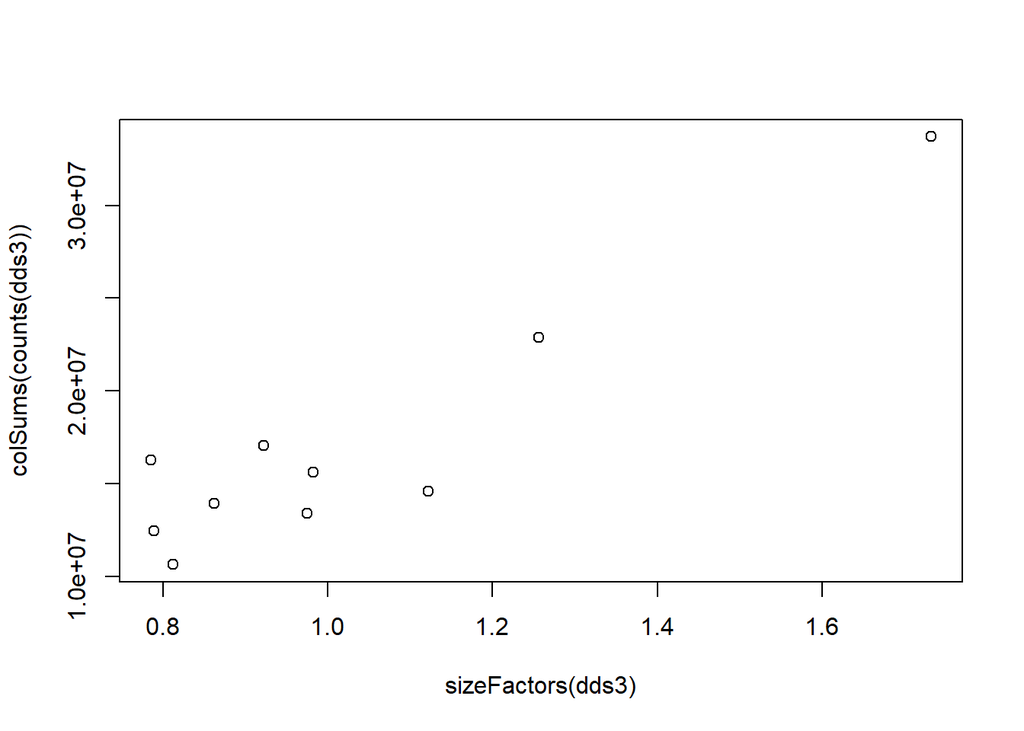

```r
plot(sizeFactors(dds3), colSums(counts(dds3)))
```

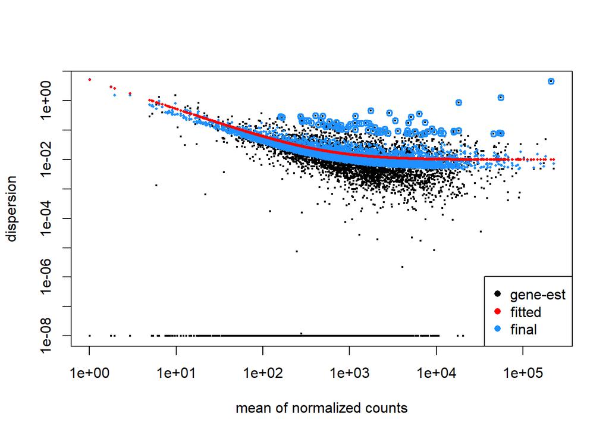

```r
plotDispEsts(dds3)
```

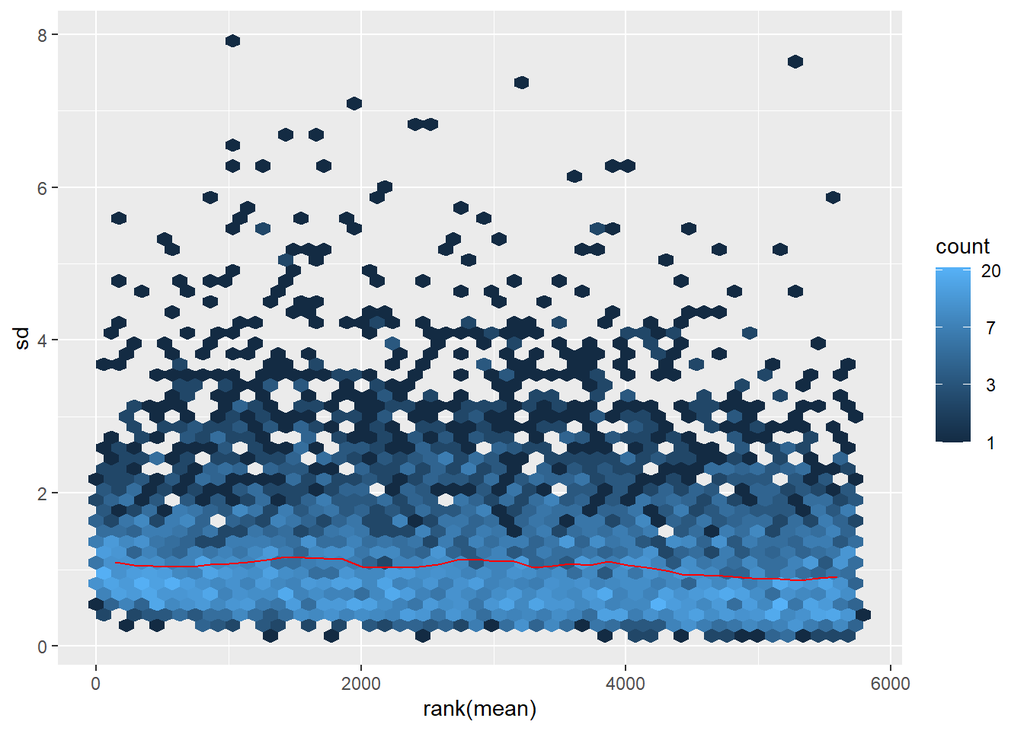

```r
vsd <- vst(dds3)
vsn::meanSdPlot(assay(vsd))
```

Now reload the primary analysis results (only if you need to)

```r
#
# combinedEffects<- fread("allDeseqOutput_DROPONE_TRUE_PAIRED_TRUE.csv")
# combinedEffectsLong <- combinedEffects |> melt(id.vars = c("Gene","NamePlant","locus_tagPlant","NameIV","locus_tagIV")) |> _[, c("Environment","score") := tstrsplit(variable,"_",fixed=TRUE)] |>
#   dcast(Gene + Environment ~ score, value.var="value") |>
#   _[ , regulated:="Neither"] |>
#   _[ L2FC>=1 & padj<=0.05 , regulated:="Up"] |>
#   _[ L2FC<= -1 & padj<=0.05 , regulated:="Down"]
#
```

Make the Excel workbook to keep all of the tables.

```r
combinedEffects[order(IV_pvalue),.(locus_tagIV,NameIV,IVShrunk_L2FC,InvitroOnly_L2FC,IV_L2FC,IV_pvalue,IVShrunk_pvalue,IV_padj,IVShrunk_padj)]
```

```
##       locus_tagIV NameIV IVShrunk_L2FC InvitroOnly_L2FC       IV_L2FC
##            <char> <char>         <num>            <num>         <num>
##    1:     P_01862  bfr_2  3.5682670794       3.51391584  3.559249e+00
##    2:     P_04157    dht  4.1404497399       4.09354453  4.139004e+00
##    3:     P_01608  bfr_1  3.9474946474       3.90818965  3.954073e+00
##    4:     P_03985         3.6207470020       3.58541042  3.629868e+00
##    5:     P_04159   preA  3.9421316366       3.89967360  3.946976e+00
##   ---
## 5734:     P_02498        -0.0004636457      -0.04808414 -1.053731e-03
## 5735:     P_00998 argO_1 -0.0001131025      -0.04632535 -1.207268e-03
## 5736:     P_02837         0.0013367277      -0.04426778  3.676986e-04
## 5737:     P_02543         0.0014200913      -0.04458050  1.506349e-03
## 5738:     P_02795 rhaR_3  0.0011418392      -0.04513262  6.748345e-05
##           IV_pvalue IVShrunk_pvalue       IV_padj IVShrunk_padj
##               <num>           <num>         <num>         <num>
##    1:  0.000000e+00    0.000000e+00  0.000000e+00  0.000000e+00
##    2: 3.452177e-287   3.452177e-287 9.904296e-284 9.904296e-284
##    3: 1.007963e-251   1.007963e-251 1.927897e-248 1.927897e-248
##    4: 8.392573e-228   8.392573e-228 1.203915e-224 1.203915e-224
##    5: 2.283100e-210   2.283100e-210 2.620086e-207 2.620086e-207
##   ---
## 5734:  9.966682e-01    9.966682e-01  9.973635e-01  9.973635e-01
## 5735:  9.971281e-01    9.971281e-01  9.976497e-01  9.976497e-01
## 5736:  9.975145e-01    9.975145e-01  9.978623e-01  9.978623e-01
## 5737:  9.978187e-01    9.978187e-01  9.979926e-01  9.979926e-01
## 5738:  9.997163e-01    9.997163e-01  9.997163e-01  9.997163e-01
```

```r
pformat = function(x) ifelse(x==0,"<1e-300",sprintf("%0.3e",x))
lformat = function(x) sprintf("%0.3f",x)
combinedEffectsInVitroReports <- combinedEffects[order(-IVShrunk_L2FC),.(
                                        "Locus Tag"=locus_tagIV,
                                        "Name"=NameIV,
                                        "Base mean"=InvitroOnly_baseMean,
                                        "Log2 Fold change (raw)"=lformat(IV_L2FC),
                                        "Log2 Fold change (shrunk)"=lformat(IVShrunk_L2FC),
                                        "P-value"=pformat(IVShrunk_pvalue),
                                        "P-adj."=pformat(IVShrunk_padj))]
head(combinedEffectsInVitroReports,40)
```

```
##     Locus Tag   Name  Base mean Log2 Fold change (raw)
##        <char> <char>      <num>                 <char>
##  1:   P_04157    dht  7173.6205                  4.139
##  2:   P_01608  bfr_1  8049.6255                  3.954
##  3:   P_04159   preA  2406.7658                  3.947
##  4:   P_03988   araC 10984.1358                  3.729
##  5:   P_03987 ttuB_3  3199.3247                  3.646
##  6:   P_03985         4194.7892                  3.630
##  7:   P_01862  bfr_2 10030.7502                  3.559
##  8:   P_03986         3244.6064                  3.560
##  9:   P_04158   preT  1979.5121                  3.291
## 10:   P_03984         2060.6814                  3.048
## 11:   P_02836   mdeA  9978.6147                  2.917
## 12:   P_03983 araF_1  1423.5986                  2.901
## 13:   P_03798   antA   659.0282                  2.712
```

[output cut: 71 more lines]

```r
tail(combinedEffectsInVitroReports,40)[order(.N:1)]
```

```
##     Locus Tag   Name  Base mean Log2 Fold change (raw)
##        <char> <char>      <num>                 <char>
##  1:   P_04594   mbtH  1554.7752                 -5.476
##  2:   P_05434   pvdA  5400.3396                 -5.213
##  3:   P_03652         1818.5822                 -4.855
##  4:   P_00020 trpC_1  1926.3241                 -4.685
##  5:   P_03369         1453.2319                 -4.593
##  6:   P_04595    dat  2240.2515                 -4.580
##  7:   P_03650   pkn1   763.7554                 -4.310
##  8:   P_01992   hasA  3780.4303                 -4.217
##  9:   P_01660   metE  7021.9458                 -3.884
## 10:   P_03835 prsD_2  1421.6564                 -3.874
## 11:   P_03645 tycB_2   457.4279                 -3.874
## 12:   P_05790         1072.0860                 -3.799
## 13:   P_03367   lgrB 13514.8623                 -3.840
```

[output cut: 71 more lines]

```r
combinedEffectsInPlantaReports <- combinedEffects[!is.na(PlantShrunk_padj)][order(-PlantShrunk_L2FC),.("Base mean"=PlantOnly_baseMean,
                                                                         "Locus Tag"=locus_tagPlant,
                                                                         "Name"=NamePlant,
                                                                         "Log2 Fold change (raw)"=lformat(Plant_L2FC),
                                                                         "Log2 Fold change (shrunk)"=lformat(PlantShrunk_L2FC),
                                                                         "P-value"=pformat(PlantShrunk_pvalue),
                                                                         "P-adj."=pformat(PlantShrunk_padj))]
library(openxlsx)

wb=createWorkbook()
addWorksheet(wb,"Summary")
addWorksheet(wb,"Intersection")
addWorksheet(wb,"In planta upregulated")
addWorksheet(wb,"In planta downregulated")
addWorksheet(wb,"In vitro upregulated")
addWorksheet(wb,"In vitro downregulated")
addWorksheet(wb,"All results")
writeData(wb,"Summary",combinedEffectsLong[, table(regulated,Environment)])
writeData(wb,"In planta upregulated",head(combinedEffectsInPlantaReports,40))
writeData(wb,"In planta downregulated",tail(combinedEffectsInPlantaReports,40)[order(.N:1)])
writeData(wb,"In vitro upregulated",head(combinedEffectsInVitroReports,40))
writeData(wb,"In vitro downregulated",tail(combinedEffectsInVitroReports,40)[order(.N:1)])
writeData(wb,"All results",combinedEffects)

pairedRegulated <- combinedEffectsLong[Environment %in% c("Plant","IV"), .(Gene,Environment,regulated)] |>
  dcast(Gene~Environment) |>
  _[,table(IV,Plant)]

pairedRegulated
```

```
##          Plant
## IV        Down Neither   Up
##   Down       1     413    1
##   Neither   51    5010   25
##   Up         7     229    1
```

```r
discordantGenes <- combinedEffectsLong[Environment %in% c("Plant","IV"), .(Gene,Environment,regulated)] |>
  dcast(Gene~Environment) |>
  _[Plant!="Neither" & IV!="Neither"] |>
  _[order(IV,Plant)]
```

These aren’t all discordant, it’s just the list of the genes that are significant in both models.  
Turns out most are discordant.

```r
discordantGenes <- IVGeneNames[discordantGenes , on="Gene"]

discordantGenes
```

```
##               Gene NameIV locus_tagIV     IV  Plant
##             <char> <char>      <char> <char> <char>
##  1: nbis-gene-1647   metE     P_01660   Down   Down
##  2: nbis-gene-5062 arcD_1     P_05120   Down     Up
##  3: nbis-gene-1385            P_01397     Up   Down
##  4: nbis-gene-1660            P_01673     Up   Down
##  5: nbis-gene-3618            P_03656     Up   Down
##  6: nbis-gene-3944 ttuB_3     P_03987     Up   Down
##  7: nbis-gene-3945   araC     P_03988     Up   Down
##  8:  nbis-gene-566            P_00571     Up   Down
##  9:  nbis-gene-567  dxs_1     P_00572     Up   Down
## 10:  nbis-gene-853 nemR_2     P_00861     Up     Up
```

```r
writeData(wb,"Intersection",pairedRegulated)
writeData(wb,"Intersection",discordantGenes,startRow = 10)


saveWorkbook(wb, "DeseqResults.xlsx",overwrite=TRUE)


combinedEffectsLong[Environment %in% c("Plant","IV"), .(Gene,Environment,regulated)] |>
  dcast(Gene~Environment) |>
  _[,table(IV,Plant)] |> chisq.test()
```

```
##
##  Pearson's Chi-squared test
##
## data:  dcast(combinedEffectsLong[Environment %in% c("Plant", "IV"),     .(Gene, Environment, regulated)], Gene ~ Environment)[, table(IV,     Plant)]
## X-squared = 11.731, df = 4, p-value = 0.01947
```

```r
## Kendall's tau for the concordance between environments.
combinedEffectsLong[Environment %in% c("Plant","IV"), .(Gene,Environment,regulated)] |> dcast(Gene~Environment) |>
  _[,table(IV,Plant)] |>
  DescTools::KendallTauB(conf.level=0.95)
```

```
##        tau_b       lwr.ci       upr.ci
## -0.029044018 -0.055094950 -0.002993086
```